# R Homework The Analytics Edge Unit 1

An analitical detective https://learning.edx.org/course/course-v1:MITx+15.071x+2T2020/block-v1:MITx+15.071x+2T2020+type@sequential+block@a5915d0492804dada5feb1926ba5be7a/block-v1:MITx+15.071x+2T2020+type@vertical+block@c19c29adcea24760985949691e8019a4 https://data.cityofchicago.org/Public-Safety/Crimes-2001-to-present/ijzp-q8t2

Problem 1.1 - Loading the Data How many rows of data (observations) are in this dataset? 191641 Problem 1.2 - Loading the Data How many variables are in this dataset? 11

```r
# Structure of the dataset
  str(df)
```

```
'data.frame':   191641 obs. of  11 variables:
 $ ID                 : int  8951354 8951141 8952745 8952223 8951608 8950793 8950760 8951611 8951802 8950706 ...
 $ Date               : chr  "12/31/12 23:15" "12/31/12 22:00" "12/31/12 22:00" "12/31/12 22:00" ...
 $ LocationDescription: chr  "STREET" "STREET" "RESIDENTIAL YARD (FRONT/BACK)" "STREET" ...
 $ Arrest             : logi  FALSE FALSE FALSE FALSE FALSE TRUE ...
 $ Domestic           : logi  FALSE FALSE FALSE FALSE FALSE FALSE ...
 $ Beat               : int  623 1213 1622 724 211 2521 423 231 1021 1215 ...
 $ District           : int  6 12 16 7 2 25 4 2 10 12 ...
 $ CommunityArea      : int  69 24 11 67 35 19 48 40 29 24 ...
 $ Year               : int  2012 2012 2012 2012 2012 2012 2012 2012 2012 2012 ...
 $ Latitude           : num  41.8 41.9 42 41.8 41.8 ...
 $ Longitude          : num  -87.6 -87.7 -87.8 -87.7 -87.6 ...
```

```r
which.max(df$ID)
```

```
[1] 18134
```

```r
which.min(df$Beat)
```

```
[1] 4756
```

Problem 1.5 - Loading the Data How many observations have value TRUE in the Arrest variable (this is the number of crimes for which an arrest was made)? 15536

```r
table(df$Arrest)
```

```
 FALSE   TRUE
176105  15536
```

```r
match("ALLEY", df$LocationDescription)
```

```
[1] 46
```

Problem 2.1 - Understanding Dates in R In many datasets, like this one, you have a date field. Unfortunately, R does not automatically recognize entries that look like dates. We need to use a function in R to extract the date and time. Take a look at the first entry of Date (remember to use square brackets when looking at a certain entry of a variable).

In what format are the entries in the variable Date? Month/Day/Year Hour:Minute

```r
df$Date[1]
```

```
[1] "12/31/12 23:15"
```

Problem 2.2 - Understanding Dates in R

Now, let’s convert these characters into a Date object in R. In your R console, type

DateConvert = as.Date(strptime(mvt$Date, “%m/%d/%y %H:%M”))

This converts the variable “Date” into a Date object in R. Take a look at the variable DateConvert using the summary function.

What is the month and year of the median date in our dataset? Enter your answer as “Month Year”, without the quotes. (Ex: if the answer was 2008-03-28, you would give the answer “March 2008”, without the quotes.) May 2006

```r
median(DateConvert, na.rm=TRUE)
```

```
[1] "2006-05-21"
```

Problem 2.3 - Understanding Dates in R Now, let’s extract the month and the day of the week, and add these variables to our data frame mvt. We can do this with two simple functions. Type the following commands in R:

```r
df$Month = months(DateConvert)
```

[output not shown]

Using the table command, answer the following questions. In which month did the fewest motor vehicle thefts occur? Febrero 13511

```r
table(df$Month)
```

```
     abril     agosto  diciembre      enero    febrero      julio      junio
     15280      16572      16426      16047      13511      16801      16002
     marzo       mayo  noviembre    octubre septiembre
     15758      16035      16063      17086      16060
```

On which weekday did the most motor vehicle thefts occur? viernes 29284

```r
table(df$Weekday)
```

```
  domingo    jueves     lunes    martes miércoles    sábado   viernes
    26316     27319     27397     26791     27416     27118     29284
```

Problem 2.5 - Understanding Dates in R Which month has the largest number of motor vehicle thefts for which an arrest was made? Enero 1435

```r
table(df$Arrest, df$Month)
```

```
        abril agosto diciembre enero febrero julio junio marzo  mayo noviembre
  FALSE 14028  15243     15029 14612   12273 15477 14772 14460 14848     14807
  TRUE   1252   1329      1397  1435    1238  1324  1230  1298  1187      1256

        octubre septiembre
  FALSE   15744      14812
  TRUE     1342       1248
```

Problem 3.1 - Visualizing Crime Trends

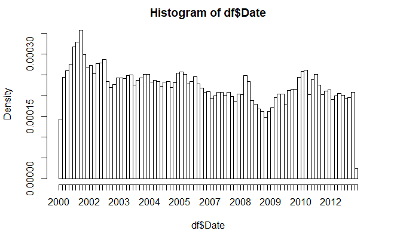

In general, does it look like crime increases or decreases from 2002 - 2012? In general, does it look like crime increases or decreases from 2005 - 2008? In general, does it look like crime increases or decreases from 2009 - 2011?